# V3_Entrega_Montoya_Arcuschin

2024-07-10

# 1. Introducción

```r
library(tidyverse)
library(haven)
library(openxlsx)
library(kableExtra)
library(survey)
library(gmodels)
library(questionr)
library(FactoMineR)
library(readr)
library(esquisse)
library(rio)

setwd("C:/Users/melod/Escritorio/Estudio/Posgrado/2024/Mercado de trabajo/Evaluación/Evaluacion/")
bolivia<- readRDS("Bolivia_1a4T2019.RDS")
chile <- read.csv2("Chile_2019.csv")
```

# 2. Bolivia

En lo caso de la encuesta de Bolivia, se utilizaron las siguientes variables:

- pea → “La Población Económicamente Activa (PEA) corresponde a aquellas personas de 14 años o más de edad que en la semana que fueron encuestadas declararon: a) que trabajaron al menos una hora en la semana de referencia, b) que por razones circunstanciales no trabajaron, pero cuentan con una fuente laboral; c) o que no trabajaron, pero buscaron trabajo durante las últimas cuatro semanas además de estar disponibles para trabajar. La PEA es el conjunto de personas ocupadas y desocupadas.”
- fact_trim → “Cantidad de unidades (personas) que representa una unidad (persona) de la muestra de forma trimestral”
- peao → “La Población Ocupada corresponde a personas de 14 años de edad o más que hubiesen trabajado más de una hora en la semana de referencia”
- pead → “La Población Desocupada corresponde a las personas de 14 años o más de edad que: no tienen trabajo, están disponibles para trabajar y lo buscan activamente; es decir, en la semana que fueron encuestadas declararon que no trabajaron ni una hora en la semana de referencia, a pesar de que realizaron acciones de búsqueda de un empleo o intentaron ejercer una actividad por su cuenta, durante las últimas cuatro semanas”
- s2_26a → Sirve para “indagar sobre la cantidad de personal que trabaja en la institución, considerando que se debe aproximar según la existencia de la empresa en distintos lugares dentro del país”
- s2_17a→ Sirve para “determinar si existe una relación de dependencia o no, o si se trata de una trabajador familiar no remunerado”
- s2_21 →“Esta pregunta permite [conocer] el tipo de relación contractual que tienen los trabajadores con sus empleadores para los casos exclusivos de declaración como Obreros o Empleados en la categoría ocupacional”
- s2_21a → “Esta pregunta permite [conocer] el tipo de relación contractual en términos de tiempo”
- s1_07a → “El Nivel Educativo es la declaración del nivel de instrucción más alto que una persona ha alcanzado según el sistema educativo boliviano”
- s2_18→ Sirve para “conocer la relación del trabajador con su empleo, es decir, la forma que tiene de insertarse en el mercado laboral (…)”

Para el análisis de este país utilizaremos distintos conceptos. Uno es el de “Población Económicamente Activa” (PEA), que incluye tanto a los ocupados como a los desocupados. La tasa de actividad, que es la suma de la PEA sobre el total de población, es 51%. Esto último implica que aproximadamente la mitad de los habitantes de Bolivia son inactivos.

Por su parte, aproximadamente el 4% de los participantes de la PEA son desocupados. Es decir, son personas de 14 años o más que no tienen trabajo, están disponibles para trabajar y lo buscan de forma activa.

Sin embargo, conocer la cantidad de los ocupados (aproximadamente el 96% de la PEA) no implica conocer la calidad de dicho empleo. Es este sentido, pueden resultar enriquecedoras la tasa de informalidad y la de precariedad. En el primer caso, tomamos como “informales” aquellos ocupados que reúnen una de las siguientes condiciones:

1. Son empleados, obreros o empleadores que trabajan para instituciones con menos de 10 empleados.
2. Son trabajadores por cuenta propia que poseen un nivel educativo inferior al catalogado por la encuesta como “educación superior”
3. Son cooperativistas de producción, trabajadores familiares sin remuneración o aprendices/personas en formación sin remuneración

Por otro lado, la precariedad la calificamos si ocurre alguno de los siguientes escenarios:

1. Son asalariados sin contrato firmado.
2. Son asalariados con un contrato firmado por 6 meses o menos.

En consecuencia, si se analiza el mercado de trabajo en Bolivia, prestar atención a la desocupación no basta. En este sentido, se observa que la tasa de actividad es aproximadamente la mitad de la población. A su vez, la informalidad representa el 52% de los ocupados y la precariedad poco menos que la mitad de los asalariados (45, 7%).

Observemos a continuación los indicadores expresados.

## 2.1 Indicadores generales

```r
#Se calcula la PEA, los ocupados, los desocupados y el universo de estudio.
suma_pea <- sum(bolivia$fact_trim[bolivia$pea == 1], na.rm = TRUE)
suma_ocupados <- sum(bolivia$fact_trim[bolivia$peao == 1], na.rm = TRUE)
suma_desocupados <- suma_pea-suma_ocupados
suma_total <- sum(bolivia$fact_trim, na.rm = TRUE)

#Se arma una columna que califica en desocupados, ocupados informales y ocupados formales.
bolivia <- bolivia %>%
  mutate(empleo = case_when(
    pea == 1 & peao != 1 ~ "no ocupado",
    peao == 1 & (
      (s2_26a <= 2 & (s2_18 %in% c(1, 3, 7) | s2_17a == 2)) |
      (s1_07a < 71 & s2_18 == 2) |
      (s2_18 %in% c(4, 5, 6))
    ) ~ "Informal",
    peao == 1 ~ "Formal"
  ))

#Se contabiliza a los informales.
informales <- sum(bolivia$fact_trim[bolivia$empleo == ("Informal")], na.rm = TRUE)


#Se contabiliza a los asalariados.
asalariados <- sum(bolivia$fact_trim[(bolivia$s2_17a == 2)|(bolivia$s2_18 %in% c(1, 3, 7))], na.rm = TRUE)

#Se crea una columna que clasifica en asalariados precarios y no precarios.Esto es solamente para los asalariados.
bolivia <- bolivia %>%
  filter(s2_17a == 2 | s2_18 %in% c(1, 3, 7)) %>%
  mutate(precariedad = ifelse(s2_21 %in% c(2, 3, 5) | s2_21a != 3, "precario", "no precario"))

#Se contabiliza a los asalariados precarios.
asalariados_precarios <- sum(bolivia$fact_trim[bolivia$precariedad == "precario"], na.rm = TRUE)

#Se calculan las tasas.
TA_B = suma_pea/suma_total
TD_B = suma_desocupados/suma_pea
TI_B = informales/suma_ocupados
TP_B = asalariados_precarios/asalariados
```

```r
#Se redondean los valores
TA_B<-round((TA_B*100), digits =1)
TD_B<-round((TD_B*100), digits =1)

#Se crea la tabla de datos generales
DatosgeneralesBolivia<-tibble(Ocupados=suma_ocupados, Desocupados=suma_desocupados, "Población total"=suma_total, "Población Económicamente Activa" =suma_pea, "Tasa de Actividad"= TA_B, "Tasa de desocupación"=TD_B)

DatosgeneralesBolivia<-t(DatosgeneralesBolivia)

kable(DatosgeneralesBolivia, caption = "Datos generales del mercado de trabajo de trabajo boliviano (2019)")
```

Datos generales del mercado de trabajo de trabajo boliviano (2019)

| Ocupados | 22772761.5 |
| --- | --- |
| Desocupados | 872984.9 |
| Población total | 45961012.0 |
| Población Económicamente Activa | 23645746.4 |
| Tasa de Actividad | 51.4 |
| Tasa de desocupación | 3.7 |

## 2.2 Empleo formal e informal, precariedad.

```r
InformalidadPrecaridadBolivia<-tibble("Tasa de informalidad (%)"=round((TI_B*100), digits = 1), "Tasa de asalariados precarios (%)"=round((TP_B*100), digits = 1))
InformalidadPrecaridadBolivia<-t(InformalidadPrecaridadBolivia)
kable(InformalidadPrecaridadBolivia, caption = "Tasa de informalidad y de precariedad en Bolivia")
```

Tasa de informalidad y de precariedad en Bolivia

| Tasa de informalidad (%) | 52.0 |
| --- | --- |
| Tasa de asalariados precarios (%) | 45.7 |

## 2.3 Relación entre sexo e informalidad

```r
## Recoding bolivia$sexo
bolivia$sexo <- bolivia$s1_02 %>% as.character() %>% fct_recode(
    "Hombre" = "1",
    "Mujer" = "2")

bolivia_informalidad <- bolivia %>%
  filter(peao == 1)

survey<-svydesign(id=~1, weights = ~fact_trim, data = bolivia_informalidad)
weighted_table<-svytable(~empleo + sexo, design = survey)
weighted_data<-as.data.frame(weighted_table)
weighted_cross_table<-xtabs(Freq~empleo + sexo, data = weighted_data)

CrossTable(weighted_cross_table, prop.chisq = FALSE, format = "SPSS", digits = 1)
```

```
##
##    Cell Contents
## |-------------------------|
## |                   Count |
## |             Row Percent |
## |          Column Percent |
## |           Total Percent |
## |-------------------------|
##
## Total Observations in Table:  8489317
##
##              | sexo
##       empleo |          Hombre  |           Mujer  |        Row Total |
## -------------|------------------|------------------|------------------|
##       Formal |         5244443  |         3200316  |         8444759  |
##              |            62.1% |            37.9% |            99.5% |
##              |            99.7% |            99.2% |                  |
##              |            61.8% |            37.7% |                  |
## -------------|------------------|------------------|------------------|
##     Informal |           17953  |           26603  |           44556  |
##              |            40.3% |            59.7% |             0.5% |
##              |             0.3% |             0.8% |                  |
##              |             0.2% |             0.3% |                  |
## -------------|------------------|------------------|------------------|
## Column Total |         5262397  |         3226919  |         8489316  |
##              |            62.0% |            38.0% |                  |
## -------------|------------------|------------------|------------------|
##
##
```

## 2.4 Relación entre edad e informalidad

```r
bolivia <- bolivia %>%
  mutate(edad = case_when(
    s1_03a >= 15 & s1_03a <= 20 ~ "de 15 a 20",
    s1_03a > 20 & s1_03a <= 40 ~ "de 21 a 40",
    s1_03a > 40 & s1_03a <= 60 ~ "de 41 a 60",
    s1_03a > 60 & s1_03a <= 80 ~ "de 61 a 80",
    s1_03a > 80 ~ "mayor de 80"
  ))

bolivia_informalidad <- bolivia %>%
  filter(peao == 1)

survey<-svydesign(id=~1, weights = ~fact_trim, data = bolivia_informalidad)
weighted_table<-svytable(~edad + empleo, design = survey)
weighted_data<-as.data.frame(weighted_table)
weighted_cross_table<-xtabs(Freq~edad + empleo, data = weighted_data)

CrossTable(weighted_cross_table, prop.chisq = FALSE, format = "SPSS", digits = 1)
```

```
##
##    Cell Contents
## |-------------------------|
## |                   Count |
## |             Row Percent |
## |          Column Percent |
## |           Total Percent |
## |-------------------------|
##
## Total Observations in Table:  8465209
##
##              | empleo
##         edad |          Formal  |        Informal  |        Row Total |
## -------------|------------------|------------------|------------------|
##   de 15 a 20 |          675475  |            7918  |          683393  |
##              |            98.8% |             1.2% |             8.1% |
##              |             8.0% |            18.1% |                  |
##              |             8.0% |             0.1% |                  |
## -------------|------------------|------------------|------------------|
##   de 21 a 40 |         4846528  |           31253  |         4877781  |
##              |            99.4% |             0.6% |            57.6% |
##              |            57.5% |            71.4% |                  |
##              |            57.3% |             0.4% |                  |
## -------------|------------------|------------------|------------------|
##   de 41 a 60 |         2480121  |            2419  |         2482540  |
##              |            99.9% |             0.1% |            29.3% |
##              |            29.5% |             5.5% |                  |
##              |            29.3% |             0.0% |                  |
## -------------|------------------|------------------|------------------|
##   de 61 a 80 |          410946  |            2195  |          413141  |
##              |            99.5% |             0.5% |             4.9% |
##              |             4.9% |             5.0% |                  |
##              |             4.9% |             0.0% |                  |
## -------------|------------------|------------------|------------------|
##  mayor de 80 |            8352  |               0  |            8352  |
##              |           100.0% |             0.0% |             0.1% |
##              |             0.1% |             0.0% |                  |
##              |             0.1% |             0.0% |                  |
## -------------|------------------|------------------|------------------|
## Column Total |         8421423  |           43785  |         8465209  |
##              |            99.5% |             0.5% |                  |
## -------------|------------------|------------------|------------------|
##
##
```

## 2.5 Relación entre sexo/precariedad

```r
bolivia_precariedad <- bolivia %>%
  filter(s2_17a == 2 | s2_18 %in% c(1, 3, 7)) %>%
  mutate(precariedad = ifelse(s2_21 %in% c(2, 3, 5) | s2_21a != 3, "precario", "no precario"))

survey<-svydesign(id=~1, weights = ~fact_trim, data = bolivia_precariedad)
weighted_table<-svytable(~precariedad + sexo, design = survey)
weighted_data<-as.data.frame(weighted_table)
weighted_cross_table<-xtabs(Freq~precariedad + sexo, data = weighted_data)

CrossTable(weighted_cross_table, prop.chisq = FALSE, format = "SPSS", digits = 1)
```

```
##
##    Cell Contents
## |-------------------------|
## |                   Count |
## |             Row Percent |
## |          Column Percent |
## |           Total Percent |
## |-------------------------|
##
## Total Observations in Table:  4783712
##
##              | sexo
##  precariedad |          Hombre  |           Mujer  |        Row Total |
## -------------|------------------|------------------|------------------|
##  no precario |          532109  |          358604  |          890714  |
##              |            59.7% |            40.3% |            18.6% |
##              |            16.6% |            22.6% |                  |
##              |            11.1% |             7.5% |                  |
## -------------|------------------|------------------|------------------|
##     precario |         2667865  |         1225132  |         3892997  |
##              |            68.5% |            31.5% |            81.4% |
##              |            83.4% |            77.4% |                  |
##              |            55.8% |            25.6% |                  |
## -------------|------------------|------------------|------------------|
## Column Total |         3199974  |         1583737  |         4783711  |
##              |            66.9% |            33.1% |                  |
## -------------|------------------|------------------|------------------|
##
##
```

```r
#Corroboramos los datos para comparar con la tasa de precariedad.
proporcion_precario_ponderada <- bolivia_precariedad %>%
  summarise(proporcion = sum((precariedad == "precario") * fact_trim, na.rm = TRUE) /
                         sum(fact_trim, na.rm = TRUE))

print(proporcion_precario_ponderada)
```

```
## # A tibble: 1 × 1
##   proporcion
##        <dbl>
## 1      0.457
```

## 2.6 Relación entre edad e precariedad

```r
survey<-svydesign(id=~1, weights = ~fact_trim, data = bolivia_precariedad)
weighted_table<-svytable(~edad + precariedad, design = survey)
weighted_data<-as.data.frame(weighted_table)
weighted_cross_table<-xtabs(Freq~edad + precariedad, data = weighted_data)

CrossTable(weighted_cross_table, prop.chisq = FALSE, format = "SPSS", digits = 1)
```

```
##
##    Cell Contents
## |-------------------------|
## |                   Count |
## |             Row Percent |
## |          Column Percent |
## |           Total Percent |
## |-------------------------|
##
## Total Observations in Table:  4740245
##
##              | precariedad
##         edad |     no precario  |        precario  |        Row Total |
## -------------|------------------|------------------|------------------|
##   de 15 a 20 |           18028  |          584418  |          602446  |
##              |             3.0% |            97.0% |            12.7% |
##              |             2.0% |            15.2% |                  |
##              |             0.4% |            12.3% |                  |
## -------------|------------------|------------------|------------------|
##   de 21 a 40 |          612485  |         2434587  |         3047072  |
##              |            20.1% |            79.9% |            64.3% |
##              |            68.8% |            63.2% |                  |
##              |            12.9% |            51.4% |                  |
## -------------|------------------|------------------|------------------|
##   de 41 a 60 |          233463  |          719304  |          952768  |
##              |            24.5% |            75.5% |            20.1% |
##              |            26.2% |            18.7% |                  |
##              |             4.9% |            15.2% |                  |
## -------------|------------------|------------------|------------------|
##   de 61 a 80 |           25510  |          109780  |          135290  |
##              |            18.9% |            81.1% |             2.9% |
##              |             2.9% |             2.9% |                  |
##              |             0.5% |             2.3% |                  |
## -------------|------------------|------------------|------------------|
##  mayor de 80 |            1226  |            1439  |            2666  |
##              |            46.0% |            54.0% |             0.1% |
##              |             0.1% |             0.0% |                  |
##              |             0.0% |             0.0% |                  |
## -------------|------------------|------------------|------------------|
## Column Total |          890714  |         3849530  |         4740245  |
##              |            18.8% |            81.2% |                  |
## -------------|------------------|------------------|------------------|
##
##
```

# 3. Chile

## 3.1 Indicadores generales

```r
# Se detecta un problema con la variable chile$fact_cal_esi que aparece como character.
chile$fact_cal_esi <- gsub(",", ".", chile$fact_cal_esi)
chile$fact_cal_esi <- as.numeric(chile$fact_cal_esi)


#Control de los datos comparando datos del marco poblacional del registro de la encuesta. Los resultados coinciden.
chile %>% count(grupo_edad, wt=fact_cal_esi) %>% mutate(porcentaje =round((n/sum(n)*100), digits = 1))
```

```r
#Como no existe ninguna variable que indique activo/inactivo/desocupado, se procede a recodificar la variable "cse_específico", que indica los distintos tipos de perfiles y que permite reconstruir, en base a lo indicado en el registro, si se trata de la categoría ocupado, desocupado o inactivo.


chile$categoría <- chile$cse_especifico %>%
  as.character() %>%
  fct_recode(
    "Menor de 15" = "0",
    "Ocupado" = "1",
    "Ocupado" = "2",
    "Ocupado" = "3",
    "Ocupado" = "4",
    "Ocupado" = "5",
    "Ocupado" = "6",
    "Ocupado" = "7",
    "Desocupado" = "8",
    "Desocupado" = "9",
    "Inactivo" = "10",
    "Inactivo" = "11",
    "Inactivo" = "12",
    "Inactivo" = "13",
    "Inactivo" = "14",
    "Inactivo" = "15",
    "Inactivo" = "16",
    "Inactivo" = "17",
    "Inactivo" = "18",
    "Inactivo" = "19",
    "Inactivo" = "20",
    "Inactivo" = "21",
    "Inactivo" = "22",
    "Inactivo" = "23",
    "Inactivo" = "24",
    "Inactivo" = "25",
    "Inactivo" = "26",
    "Inactivo" = "27",
    "Inactivo" = "28")
```

```r
# Se procede luego a calcular los datos solicitados utilizando la categorización anterior.



t<-chile[chile$categoría=="Ocupado",]
OcupadoChile<-round(sum(t$fact_cal_esi), digits = 0)


t<-chile[chile$categoría=="Desocupado",]
DesocupadoChile<-round(sum(t$fact_cal_esi), digits = 0)


PoblTotChile<-sum(chile$fact_cal_esi)

PeaChile<-OcupadoChile+DesocupadoChile

TasaActivChile<-round((PeaChile/PoblTotChile*100), digits = 1)

TasaDesocupChile<-round((DesocupadoChile/PeaChile*100), digits = 1)

Datosgenerales<-tibble(Ocupados=OcupadoChile, Desocupados=DesocupadoChile, "Población total"=PoblTotChile,"Población Económicamente Activa"= PeaChile, "Tasa de Actividad"= TasaActivChile, "Tasa de desocupación"=TasaDesocupChile)

kable(t(Datosgenerales), caption = "Datos generales del mercado de trabajo chileno (2019)") %>%
  add_footnote(c("Fuente:Encuesta ESI 2019, INE Chile"))
```

Datos generales del mercado de trabajo chileno (2019)

| Ocupados | 9140044.0 |
| --- | --- |
| Desocupados | 668327.0 |
| Población total | 19238933.0 |
| Población Económicamente Activa | 9808371.0 |
| Tasa de Actividad | 51.0 |
| Tasa de desocupación | 6.8 |

**Note:** <sup>a</sup>Fuente:Encuesta ESI 2019, INE Chile

## 3.2 Sector formal e informal, precariedad.

La encuesta ESI contiene una variable “sector” que designa “Ocupados según sector”, se calcula entonces la tasa de informalidad usando esa variable.

```r
InformalChile<-chile %>% filter(chile$sector=="2")
InformalChile<-sum(InformalChile$fact_cal_esi)
TasaInformalidadChile<-round(InformalChile/OcupadoChile*100, digits=1)
```

Para la precariedad, se usan tres variables. En primer lugar, la variable “b8” que indica la existencia de un contrato. Se recodifican las modalidades.

```r
## Recoding chile$b8 into chile$Contrato
chile$Contrato <- chile$b8 %>%
  as.character() %>%
  fct_recode(
    "Con contrato" = "1",
    "Sin contrato" = "2"
  )
```

Se usa también la variable “b9” sobre el carácter definido o indefinido del contrato.

```r
## Recoding chile$b9 into chile$DuraciónContrato
chile$DuraciónContrato <- chile$b9 %>%
  as.character() %>%
  fct_recode(
    "Definido" = "1",
    "Indefinido" = "2"
  )
```

Y la varibale “b10”, sobre la duración del contrato.

```r
## Recoding chile$b10 into chile$DuraciónContratoDefinido
chile$DuraciónContratoDefinido <- chile$b10 %>%
  as.character() %>%
  fct_recode(
    "Temporada" = "1",
    "TérminoActividad" = "2",
    "Menos3meses" = "3",
    "RenovableAlAño" = "4",
    "Reemplazo" = "5",
    "NoSabe" = "6"
  )
```

Se crea a partir de esa variable una variable única “Precariedad” que resulta del cruce entre las tres. Luego se recodifica tomando en cuenta los criterios siguientes:

Se considera como precaria: -Toda persona sin contrato. -Toda persona con un contrato de una duración menor a 3 meses, con una duración no conocida, que se acaba con la temporada o al término de la actividad, obra o proyecto.

Se considera como no precaria: - Con contrato definido que se puede remplazar. - Con contrato defenido renovable al año. - Con contrato indefinido.

```r
# Creación de la variable precariedad
chile<-chile %>% unite("Precariedad", Contrato,DuraciónContrato,DuraciónContratoDefinido, sep = "_")

## Recoding chile$Precariedad
chile$Precariedad <- chile$Precariedad %>%
  fct_recode(
    "Precario" = "Con contrato_Definido_Menos3meses",
    "Precario" = "Con contrato_Definido_NoSabe",
    "NoPrecario" = "Con contrato_Definido_Reemplazo",
    "NoPrecario" = "Con contrato_Definido_RenovableAlAño",
    "Precario" = "Con contrato_Definido_Temporada",
    "Precario" = "Con contrato_Definido_TérminoActividad",
    "NoPrecario" = "Con contrato_Indefinido_NA",
    NULL = "NA_NA_NA",
    "Precario" = "Sin contrato_Definido_Menos3meses",
    "Precario" = "Sin contrato_Definido_NoSabe",
    "Precario" = "Sin contrato_Definido_Reemplazo",
    "Precario" = "Sin contrato_Definido_RenovableAlAño",
    "Precario" = "Sin contrato_Definido_Temporada",
    "Precario" = "Sin contrato_Definido_TérminoActividad",
    "Precario" = "Sin contrato_Indefinido_NA"
  )
PrecariosChile<-chile %>% filter(Precariedad=="Precario")
TasaPrecariedadChile<-round(sum(PrecariosChile$fact_cal_esi)/OcupadoChile*100, digits = 1)

kable(t((tibble("Tasa de informalidad"=TasaInformalidadChile, "Tasa de precariedad"=TasaPrecariedadChile))), caption = "Tasa de informalidad y de precariedad en Chile") %>%
  add_footnote(c("Fuente:Encuesta ESI 2019, INE Chile"))
```

Tasa de informalidad y de precariedad en Chile

| Tasa de informalidad | 16.3 |
| --- | --- |
| Tasa de precariedad | 20.7 |

**Note:** <sup>a</sup>Fuente:Encuesta ESI 2019, INE Chile

## 3.3 Relación entre sexo y formalidad

```r
## Recoding chile$sector
chile$sector <- chile$sector %>%
  as.character() %>%
  fct_recode(
    "Formal" = "1",
    "Informal" = "2",
    "HogaresComoEmpleadores" = "3"
  )


## Recoding chile$sexo
chile$sexo <- chile$sexo %>%
  as.character() %>%
  fct_recode(
    "Hombre" = "1",
    "Mujer" = "2"
  )



d<-chile %>% select("sector", "sexo", "fact_cal_esi")

## Reordering d$sector
d$sector <- d$sector %>%
  fct_relevel(
    "Formal", "Informal", "HogaresComoEmpleadores"
  )

d$fact_cal_esi<-round(d$fact_cal_esi, digits = 0)

d<-uncount(d, fact_cal_esi)

d<-na.omit(d)
```

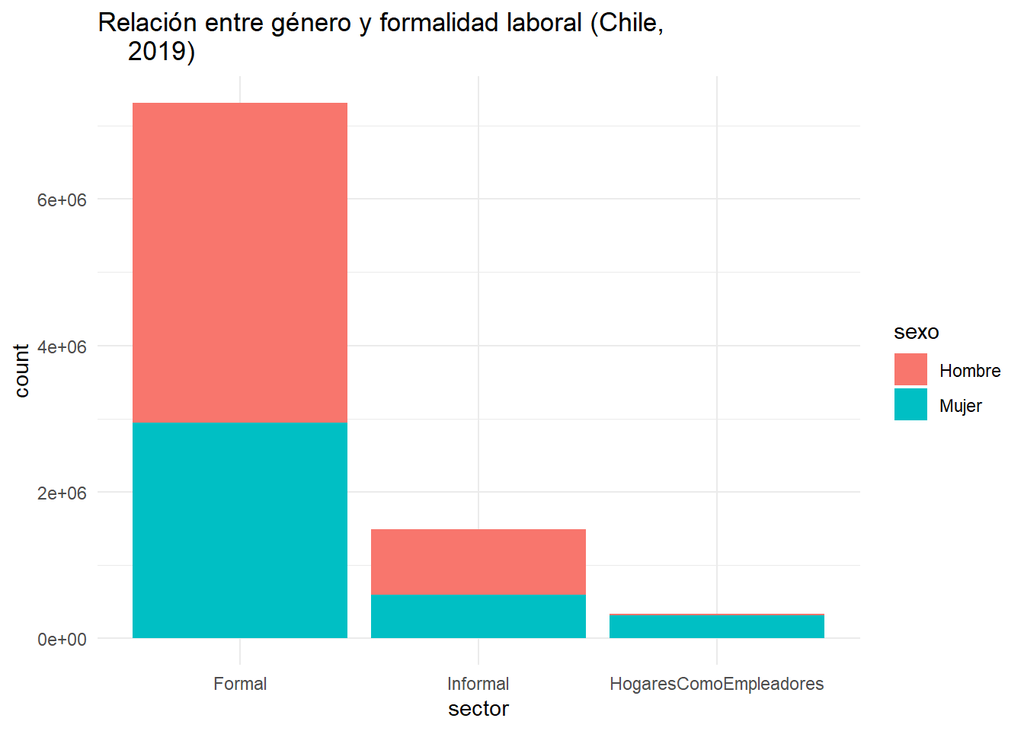

```r
ggplot(d) +
  aes(x = sector, fill = sexo) +
  geom_bar() +
  scale_fill_hue(direction = 1) +
  labs(
    title = "Relación entre género y formalidad laboral (Chile,
    2019)",
  ) +
  theme_minimal()
```

El análisis de la relación entre sexo y formalidad revela que casi 60% del sector formal son hombres y que casi 83% de los hombres están en el sector formal, porcentaje de 40% y 76% respectivamente en el caso de las mujeres. El grupo más importante son los hombres del sector formal, que representan 47,8% del total.

Cabe también señalar que 60% del sector informal son hombres y que sólo 15,4% de las mujeres se encuentran en el sector informal.

En cuanto a la modalidad “HogaresComoEmpleadores”, se trata en un 91% de mujeres.

```r
CrossTable(d$sector,d$sexo, prop.chisq = FALSE, format = "SPSS")
```

[output not shown]

La prueba del khi2 que se realizó muestra la existencia de una relación significativa entre sexo y formalidad: el valor p es casi nulo, lo cual conduce a rechazar la hipótesis nula de independencia entre las variables, y el khi2 es muy elevado, lo cual indica una relación significativa.

```r
t<-table(d$sector,d$sexo)
x<-chisq.test(t)
x
```

```
##
##  Pearson's Chi-squared test
##
## data:  t
## X-squared = 350624, df = 2, p-value < 2.2e-16
```

El estudio de los residuos estandarizados de la prueba del khi2 muestra que existe una fuera asociación entre “Hombre” y “Formal”, sector que se disocia fuertemente de “Mujer”. Esta diferencia entre sexo es menos marcada en el sector informal, aunque que se nota que existen diferencias significativas. La diferencias más importante es para la modalidad “HogaresComoEmpleadores”, muy marcadamente asociada con “Mujer”.

```r
kable(round(x$stdres, digits = 1), caption = "Residuos estandarizados de la prueba del ki2 para las variables sector y sexo")
```

Residuos estandarizados de la prueba del ki2 para las variables sector y sexo

|  | Hombre | Mujer |
| --- | --- | --- |
| Formal | 225.3 | -225.3 |
| Informal | 59.3 | -59.3 |
| HogaresComoEmpleadores | -592.1 | 592.1 |

## 3.4 Relación entre sexo y precariedad

El estudio de la relación entre precariedad y sexo muestra que 62,5% de los precarios son hombres, pero que sólo 30,1% de los hombres son precarios. En el caso de las mujeres 75,6% son no precarias, lo cual parece indicar que las precariedad es más bien característica de los hombres.

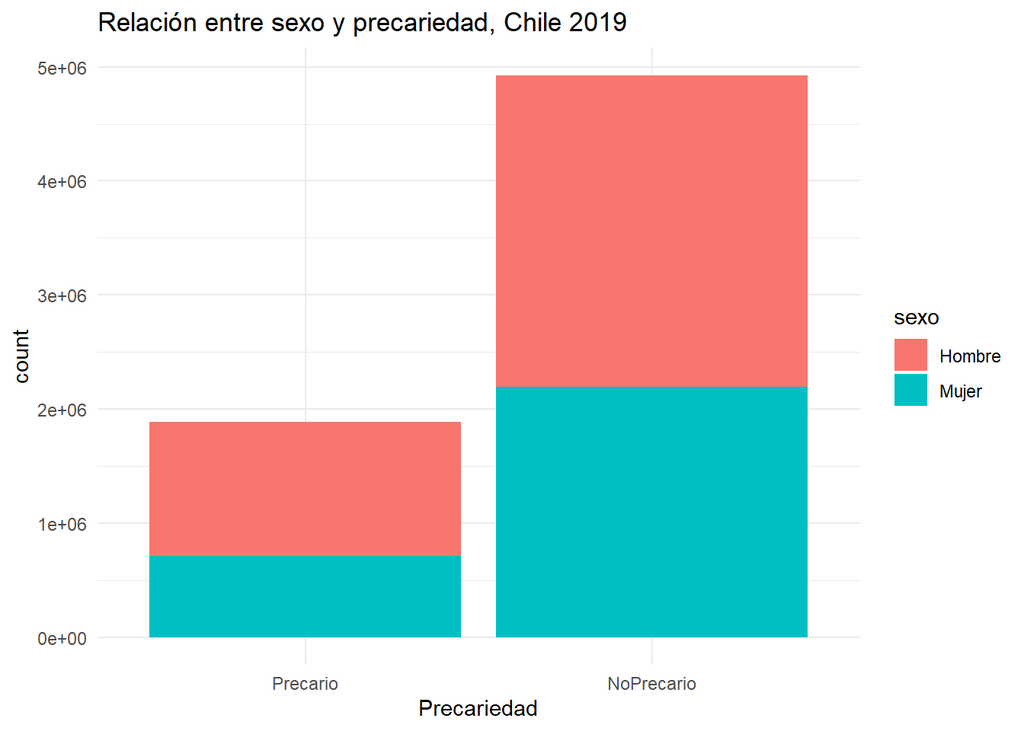

```r
d<-chile %>% select("Precariedad", "sexo", "fact_cal_esi")

d<-na.omit(d)

d$fact_cal_esi<-round(d$fact_cal_esi, digits = 0)

d<-uncount(d, fact_cal_esi)


ggplot(d) +
  aes(x = Precariedad, fill = sexo) +
  geom_bar() +
  scale_fill_hue(direction = 1) +
  labs(title = "Relación entre sexo y precariedad, Chile 2019") +
  theme_minimal()
```

```r
CrossTable(d$Precariedad,d$sexo, prop.chisq = FALSE, format = "SPSS")
```

[output not shown]

La prueba del khi2 realizada muestra que existe una relación significativa entre ambas variables.

```r
t<-table(d$Precariedad,d$sexo)
x<-chisq.test(t)
x
```

```
##
##  Pearson's Chi-squared test with Yates' continuity correction
##
## data:  t
## X-squared = 27392, df = 1, p-value < 2.2e-16
```

El análisis de los residuos estandarizados muestra que la precariedad está asociada a “hombre” mientras que la no precariedad está asociada a “Mujer”.

```r
kable(round(x$stdres, digits = 1), caption = "Residuos estandarizados de la prueba del ki2 para las variables precariedad y sexo")
```

Residuos estandarizados de la prueba del ki2 para las variables precariedad y sexo

|  | Hombre | Mujer |
| --- | --- | --- |
| Precario | 165.5 | -165.5 |
| NoPrecario | -165.5 | 165.5 |

## 3.5 Relación entre edad y formalidad

El análisis de la relación entre edad y formalidad muestra que casi 50% del sector formal tiene entre 21 y 40 año. El sector informal está compuesto en un 41,6% por personas de entre 41 y 60 años.

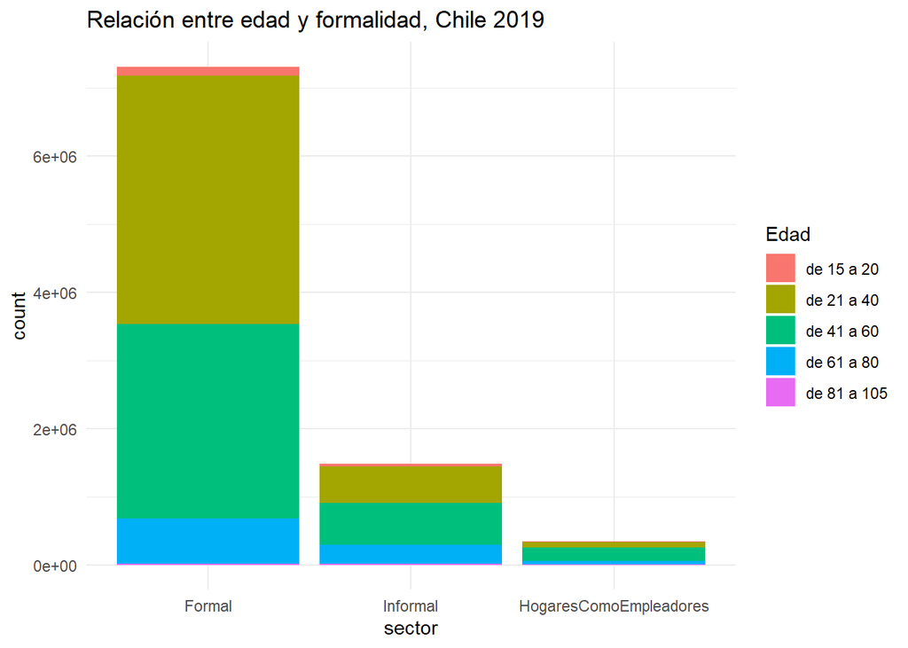

```r
## Cutting chile$edad into chile$edad_rec
chile$Edad <- cut(chile$edad,
  include.lowest = TRUE,
  right = FALSE,
  dig.lab = 4,
  breaks = c(14, 21, 41, 61, 81, 105)
)

## Recoding chile$edad_rec
chile$Edad <- chile$Edad %>%
  fct_recode(
    "de 15 a 20" = "[14,21)",
    "de 21 a 40" = "[21,41)",
    "de 41 a 60" = "[41,61)",
    "de 61 a 80" = "[61,81)",
    "de 81 a 105" = "[81,105]"
  )


d<-chile %>% select(Edad, sector, fact_cal_esi)
d$fact_cal_esi<-round(d$fact_cal_esi, digits = 0)
d<-uncount(d, fact_cal_esi)
d<-na.omit(d)

ggplot(d) +
  aes(x = sector, fill = Edad) +
  geom_bar() +
  scale_fill_hue(direction = 1) +
  labs(title = "Relación entre edad y formalidad, Chile 2019") +
  theme_minimal()
```

```r
CrossTable(d$Edad,d$sector, prop.chisq = FALSE, format = "SPSS", digits = 1)
```

[output not shown]

## 3.6 Relación entre edad y precariedad

El análisis de la relación entre edad y precariedad muestra que el rango etario comprendido entre 41 y 60 año tiene una porcentaje de precarios particularmente bajo: con 24,6% de precarios es el rango que menor porcentaje de precarios tiene comparando con el rango de 15 a 20, que alcanza el 66,5%.

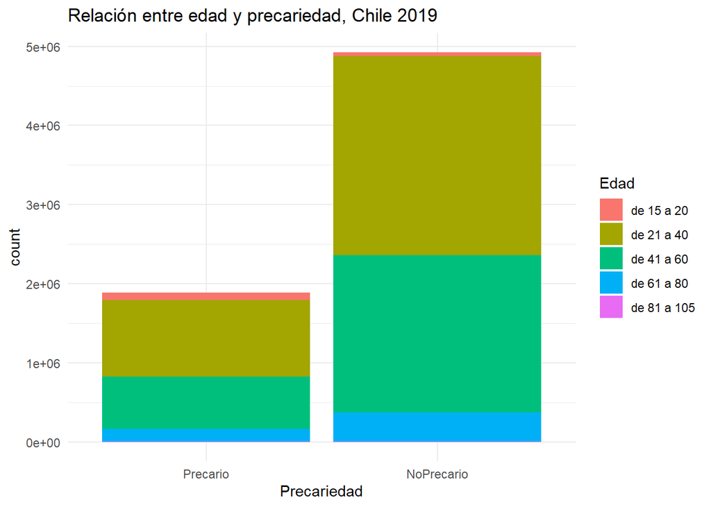

```r
d<-chile %>% select("Precariedad", "Edad", "fact_cal_esi")

d<-na.omit(d)

d$fact_cal_esi<-round(d$fact_cal_esi, digits = 0)

d<-uncount(d, fact_cal_esi)


ggplot(d) +
  aes(x = Precariedad, fill = Edad) +
  geom_bar() +
  scale_fill_hue(direction = 1) +
  labs(title = "Relación entre edad y precariedad, Chile 2019") +
  theme_minimal()
```

```r
CrossTable(d$Edad,d$Precariedad, prop.chisq = FALSE, format = "SPSS", digits = 1)
```

[output not shown]

# Conclusiones

Es de destacar los altos niveles de precariedad e informalidad comentados. En este sentido, sería interesante la comparación con países de otros continentes.

Por último, debemos comentar que nuestras variables de precariedad e informalidad no son exactamente comparables. La primera, en ambos casos, abarca a los trabajadores que no tienen contrato o que tienen un contrato corto. Sin embargo, lo que entendemos como “corto” no es igual para Bolivia que para Chile. Por su parte, la noción de “informalidad” nos resulta un interrogante en el caso chileno, ya que no tenemos conocimiento de cómo se armó dicha variable. En el caso boliviano, fue explicado oportunamente.

# Vinculación con lo visto en clase: contextualización.

Chile y Bolivia son parte de latinoamérica, región con ciertas particularidades en lo que hace a su mercado de trabajo. En este sentido, hay dos problemas que se destacan: las unidades productivas de baja productividad y la mala calidad del empleo. Justamente, en uno de los planteos en clase se definió a la informalidad como el “empleo (generalizadamente de mala calidad) en unidades productivas con características específicas, relacionadas a las particularidades de nuestra región”. Por su parte, la precariedad se vincularía con “la mala calidad del empleo, más allá de las características específicas de los mercados de trabajo en América Latina”. Sin embargo, es de destacar que ambos conceptos han tenido una trayectoria histórica compleja y cambiante. En ese sentido, y siguiendo a Koselleck, siempre resulta enriquecedor hacer historia de los diversos significantes.

Para entender las formas que puede/suele adquirir el empleo en latinoamérica es fundamental reflexionar sobre el rol de la región en el mundo. En ese sentido, nos resultó particularmente enriquecedora la propuesta de Iñigo Carrera.[1] En su planteo cobra centralidad la renta de la tierra, de la cual los países clásicos se reapropiarían. Esto se haría a través de condiciones extraordinarias para inversiones, de deuda y, desde mediados del siglo XX, del ingreso del capital fragmentado a la región. Estos últimos serían poco productivos y estarían vinculados a tecnologías obsoletas a nivel mundial. A la vez, se relacionarían con pequeños capitales nacionales. Justamente, esto permite reflexionar sobre las formas de compensación de la baja productividad de las empresas que se radican en la región.

Entonces, como parte de dicha compensación pueden aparecer ciertas características de la mano de obra y su forma de empleo. Sin embargo, por otro lado, en nuestro “sentido común” prevalece la idea de un trabajo “típico” que puede ser sinónimo de fordista. Dicho tipo de trabajo es particular de un momento histórico en occidente. Como plantean Graña y Kennedy: “La etapa de la acumulación de capital que se extendió en Estados Unidos y Europa Occidental desde la segunda guerra mundial hasta la década del setenta fue una de las más prolongadas e intensas de la historia del capitalismo. Esta se basó en la organización del proceso de producción fordista que, como regla general, intentaba incrementar la escala productiva para el pleno aprovechamiento de las economías que la tecnología permitía, profundizando al máximo la división técnica al interior de la fábrica” (2005, p.5)

Sin embargo, “a principios de la década del setenta las principales economías del mundo comienzan a enfrentar dificultades crecientes para mantener el conjunto de tales tendencias positivas” (2005, p.6). A su vez, se asiste a una computarización y automatización de los procesos productivos, lo que rendundó en la necesidad de un tipo de trabajadores: aquellos que por su inversión en la educación pudiesen manejar las nuevas tecnologías. En consecuencia, estos cambios vehiculizaron mayor heterogeneidad entre los trabajadores. En palabras de Facundo Lastra: “descalificación e intelectualización, universalización vacía y universalización científica, el carácter emancipatorio del trabajo intelectual y la explotación más brutal del trabajo simple; todos ellos son movimientos considerados en la unidad de las transformaciones de la clase trabajadora, unidad que cobra cuerpo en la diferenciación de la fuerza de trabajo.” (2018, p.238)

Siguiendo lo planteado, “la fuerza de trabajo de cada nivel de complejidad debería encerrar idéntico valor más allá de su país” (Graña, Lastra y Weksler, 2022, p.427). Sin embargo, en latinoamércia resalta que: “la calidad del empleo se ve negativamente afectada por la sobrepoblación relativa, aunque ésta influye con más intensidad sobre la mano de obra de baja calificación. Por último, la escala y tamaño de los establecimientos productivos condicionan la calidad del empleo, deteriorándose como forma de compensación a la menor productividad cuanto más pequeña es la escala de la producción.”(Graña, Lastra y Weksler, 2022, p.429). Es decir, América Latina presenta gran cantidad de puestos de trabajo en establecimientos pequeños (sobretodo de baja calificación), lo que redunda en informalidad.

En pocas palabras, en América Latina predomina una forma de trabajo informal (lo que se puede decir claramente en el caso boliviano) fruto quizá de la reapropiación de la renta de la tierra (siguiendo a Iñigo Carrera), pero a su vez muy heterogénea como consecuencia de la introducción de las nuevas tecnologías (aunque obsoletas en muchos casos) ya comentadas y del nivel educativo que se requiere para su utilización. Justamente, “la productividad que se verifica en nuestra región, no solo se caracteriza por ser más heterogénea, sino que, salvo contadas excepciones, se encuentra históricamente en niveles muy alejados de los estándares internacionales” (Fernández-Franco, Graña, Lastra y Weksler, 2022, p.128). En este sentido, es de destacar que el rezago productivo también afecta a sectores formales.

En síntesis, “pertenecer a los segmentos de mayor calificación y tamaño en los mercados de trabajo latinoamericanos está asociado a mejores condiciones laborales (…) A su vez, más allá del segmento o perfil ocupacional, encontramos que los trabajadores de los países del clúster 3 —Argentina, Brasil, Chile, Colombia, Costa Rica, México y Uruguay— tienden a mostrar indicadores más favorables en términos de cobertura en la seguridad social e ingresos respecto a los restantes países de la región”. Quizá esa es la razón de la menor precariedad e informalidad en Chile que en Bolivia. Sin embargo, “el rezago productivo opera de manera general sobre todos los trabajadores de la región, presiona particularmente sobre las condicionales laborales de los puestos de menor calificación y tamaño” (Fernández-Franco, Graña, Lastra y Weksler, 2022, p.148).

[1] También se encuentran otras posturas como las de Andy Higginbotton y John Smith, o la Teoría de la Dependencia de Marini. En ambas se retoma la noción de plusvalía absoluta para explicar la precariedad. En la primera teoría se plantea una nueva división internacional del trabajo que tiene como objetivo la superexplotación (pago de la fuerza de trabajo por debajo de su valor) en el “Sur Global”. Por su parte, Marini plantea un intercambio desigual, por la que los capitales de la periferia recurrirían al pago de la fuerza de trabajo por debajo de su valor con el objetivo de compensar el valor que pierden en el mercado mundial. Es decir, que la forma de desarrollo específica de América Latina se debería a su rol en la división internacional del trabajo (históricamente como productor de materias primas).